# Logistic Regression

BH Analytics

# Objectives

- Review of GLM Framework
- Introduce the Logistic Regression GLM model
- Understand results and output
- Predict new data

# Summarizing Discrete outcomes

```r
library(data.table)
# simulate some simple exposure/outcome data:
set.seed(42)
n_people <- 500
exposure <-
  sample(0:1,n_people,replace=T,prob=c(3,1))
outcome <-
  rbinom(n=n_people,
         size=1,
         prob=0.35 + 0.15*exposure)
# create table
df1 <-
  data.table(exposure=ifelse(exposure==1,'yes','no'),
             outcome=ifelse(outcome==1,'yes','no'))
head(df1)
```

```
##    exposure outcome
## 1:      yes      no
## 2:      yes      no
## 3:       no      no
## 4:      yes     yes
## 5:       no      no
## 6:       no     yes
```

- Now let’s take a moment to examine the overall event rate , and also the event rate by exposure. As expected, we see there is a difference in the probability of having the event depending on whether or not you had the exposure.

```r
# Investigate event rate and exposure
df1[,list(event_rate=sum(outcome=='yes')/.N)]
```

```
##    event_rate
## 1:      0.366
```

```r
df1[,list(event_rate=sum(outcome=='yes')/.N),
    by=exposure]
```

```
##    exposure event_rate
## 1:      yes  0.4262295
## 2:       no  0.3465608
```

- But, how do we summarize this difference? There’s actually multiple different options and I want to go over them. It’s important to note that we are about to see different ways of summarizing the exact same actual situation. At the end of the day, the difference in event probabilities across exposure is what we just found above .

# Different ways to summarize the same difference in risk.

- We focus on three different ways to summarize this difference in risk of the outcome. The first way is the absolute risk difference. the second way is the ratio of the risks. The third way is called the odds ratio.
- We can summarize the risk difference simply by subtracting the risk of the outcome like so:

```r
results1 <-
  df1[,list(event_rate=sum(outcome=='yes')/.N),
    by=exposure]
# absolute difference in exposure
results1[exposure=='yes',event_rate] - results1[exposure=='no',event_rate]
```

```
## [1] 0.07966866
```

- This is interpreted as the absolute difference in risk. If you are exposed, your absolute risk of the outcome is ~8% higher.
- The second way is the risk ratio. We calculate this by looking at the ratio of the outcome risk between exposed and unexposed like so:

```r
# risk ratio in exposure
results1[exposure=='yes',event_rate]/results1[exposure=='no',event_rate]
```

```
## [1] 1.229884
```

```r
# could also calculate it this way:
1 + (results1[exposure=='yes',event_rate]-results1[exposure=='no',event_rate]) / results1[exposure=='no',event_rate]
```

```
## [1] 1.229884
```

- this is a relative risk measure - so we interpret this as a percent increase in risk. Those with exposure have a 23% higher risk than those without.
- The final risk expression is an odds ratio. The odds of an event is the number of events divided by the number of non events (as opposed to the number of events divided by the total!). We calculate the odds of the event in both exposed and unexposed groups, then compare the ratio of those odds (called the odds ratio).

```r
### odds and odds ratio
# odds of getting disease in exposure == no
odds_no <-
  df1[exposure=='no',
    sum(outcome=='yes')/sum(outcome=='no')]
cat('\nThe odds of the outcome in the unexposed group is: ',odds_no)
```

```
##
## The odds of the outcome in the unexposed group is:  0.5303644
```

```r
# odds of getting disease in exposure == yes
odds_yes <-
  df1[exposure=='yes',
    sum(outcome=='yes')/sum(outcome=='no')]
cat('\nThe odds of the outcome in the exposed group is: ',odds_yes)
```

```
##
## The odds of the outcome in the exposed group is:  0.7428571
```

```r
# odds ratio (ratio of those odds)
cat('\nThe ratio of those odds is: ',odds_yes/odds_no)
```

```
##
## The ratio of those odds is:  1.400654
```

- We then interpret this by saying ‘the odds of the outcome in the exposed group are 1.4 times the odds of the outcome in the unexposed group.’
- Why do we have all these ways to summarize risk? They seem to tell a different story, even though the underlying data is the same. We are about to learn logistic regression. The natural interpretation of logistic regression will use odds ratios, so keep that in mind as we fit the models.

# General Linear Regression

- We can generalize the ordinary linear model to a more flexible framework
- In regular regression, the predictor variables are on the same scale as the outcome.
- This is often written out in the following form:

$$E(Y) = B_{0} + B_{1}*X_{1} + B_{2}*X_{2} + ... + B_{k}*X_{k} + e$$

- We could also write out this model using the distribution and matrix notation.
- We are assuming the $E(Y)$ follows a normal distribution, with a linear combination of predictors defining the mean, and the variance defined by $sigma$.

$$E(Y) \sim \text{Normal}(\mathbf X \beta,\sigma^2)$$

- Note that if we used a linear model with a binary outcome, we would be estimating absolute risk difference with the beta parameters!
- A more general framework would be to allow some function to link the predictors to the outcome, and allow different distributions other than the Normal distribution.
- We call this function the ‘link function’.In normal regression it is simply the identity function.
- We can also consider different distributional families for the outcome
- The combination of the link function and the distributional family is the general linear model.

# Logistic Regression

$$ln(\frac{P}{1-P}) = B_{0} + B_{1}*X_{1} + B_{2}*X_{2} + ... + B_{k}*X_{k}$$

- In logistic regression, we are modeling a binary process, so the outcome takes on 1 of 2 possible values
- The distributional family we use is the binomial distribution, so we assume the outcome follows a binomial distribution
- The main parameter of interest is $p$, the probability of the outcome occurrence
- We use a function called the logit function to link the additive predictor variables to the parameter $p$
- Thus, our predictor variables are on the logit scale, not on the outcome ($p$) scale!
- Logistic regression results are often reported as odds ratios, although we do not have to do that.

# Logistic Regression

$$ln(\frac{P}{1-P}) = B_{0} + B_{1}*X_{1} + B_{2}*X_{2} + ... + B_{k}*X_{k}$$

- What is our target of inference in this model?
  - P the probability of an event occurring
- Where is the error term?

# The logit function

- In normal regression, the x and y variables are on the same scale

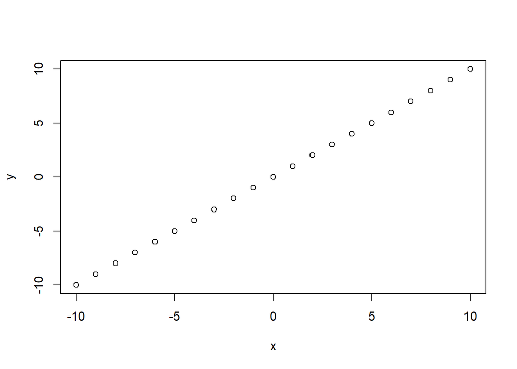

```r
# normal scale
x = -10:10
y = x
plot(x,y)
```

# The logit function

- In logistic regression, the x and y variables are related by the logit function

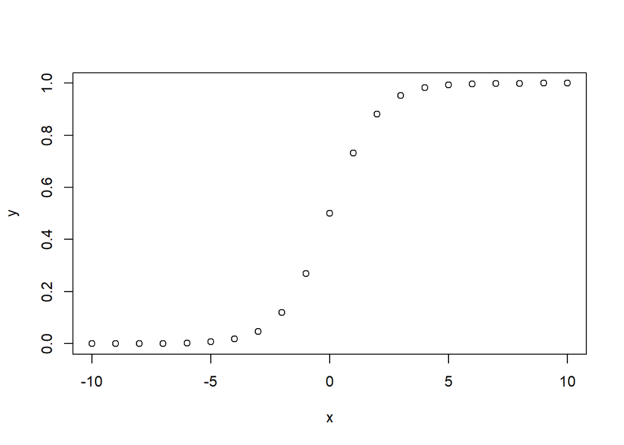

```r
# normal scale
# logit scale
y=plogis(x)
plot(x,y)
```

- Notice the boundaries of the transformation are 0 and 1, so we would not expect to predict any values smaller than 0 or higher than 1. This is a good trait for an estimator that will be predicting p, the probability of success in the binomial distribution.

We can use this function to move from the scale of the beta’s (inference equation) to the scale of the predicted probability of p. We will come back to this later using data.

# The logit function

In logistic regression, the x and y variables are related by the logit function.

$$ln(\frac{p}{(1-p)})=X$$

With a little algebra you could prove the inverse of the logit function is the following:

$$p = \frac{exp(x)}{(1+exp(x))}$$

- Note we can use the plogis and qlogis functions to go from the predictors to the outcome or vice versa

```r
# Outcome p = 0.2 to the betas
qlogis(.2)
```

```
## [1] -1.386294
```

```r
# Predictors (Beta) to the probability
plogis(1)
```

```
## [1] 0.7310586
```

# The glm function

- We use the glm function for general linear models
- We must specify the link function and the distribution
- A variety of models can be fit in this family
- Normal: link = “identity”, family=Gaussian
- Logistic: link = “logit”, family=binomial
- Poisson: link = “log”, family=poisson
- Gamma: link = “log”, family=Gamma
- check the help for “family” and “glm” for more details

```r
# sample logistic regression code
# don't run this code!
# glm(cancer ~ gender + smoking,
#     data=mydata,
#     family = binomial(link="logit"))
```

# Motivating Example: Sales Data

We will use a dataset with a binary outcome as a motivating example. This is a dataset of sales, with the outcome of interest being sale yes or no. You can generalize this setup to any situation with a binary outcome, such as estimating the probability of a customer filing a warranty claim, or perhaps the probability of a transaction being fraudulent.

We will first import this dataset and examine the potential variables.

```r
library(data.table)
library(Hmisc)
sale_df <-
  fread('Data/Data_Sims/simulated_sales_data/customer_sales1.csv')
## examine data
head(sale_df)
```

```
##    customer_id sale sale_amount region age gender activity marketing_exposure       x1        x2        x3 x4 x5 num_accounts current_customer income
## 1:      100000   No      0.0000     35  62   Male      Med                  6 73.67464  8.263063  93.87941 10  1            0               No     78
## 2:      100001  Yes    884.4780     13  71 Female     High                  5 49.19598 11.925201  72.86251  7  2            2               No     66
## 3:      100002   No      0.0000     23  53   Male     High                  6 49.86849 10.932390 128.15058 12  2            1              Yes     86
## 4:      100003   No      0.0000     12  60   Male      Med                  7 42.56315  9.725310 126.26639 11  1            0              Yes     70
## 5:      100004  Yes    243.9377     44  62   Male      Med                 11 45.03544  9.941171 108.03763  9  3            0               No     59
## 6:      100007  Yes    621.9513     42  44 Female      Low                  2 61.65991  9.152425  91.45761 10  1            1               No     60
```

```r
describe(sale_df)
```

```
## sale_df
##
##  16  Variables      8000  Observations
## --------------------------------------------------------------------------------------------------------------------------------------------------------
## customer_id
##        n  missing distinct     Info     Mean      Gmd      .05      .10      .25      .50      .75      .90      .95
##     8000        0     8000        1   104987     3329   100498   100986   102496   104989   107472   108984   109481
##
## lowest : 100000 100001 100002 100003 100004, highest: 109995 109996 109997 109998 109999
## --------------------------------------------------------------------------------------------------------------------------------------------------------
## sale
##        n  missing distinct
##     8000        0        2
##
## Value         No   Yes
## Frequency   3235  4765
## Proportion 0.404 0.596
## --------------------------------------------------------------------------------------------------------------------------------------------------------
## sale_amount
##        n  missing distinct     Info     Mean      Gmd      .05      .10      .25      .50      .75      .90      .95
##     8000        0     4737    0.934      249    320.3      0.0      0.0      0.0    118.8    418.9    697.9    875.1
##
## lowest :    0.000   10.000   10.000   10.000   10.000, highest: 1834.651 1881.856 1927.765 2075.270 2111.991
## --------------------------------------------------------------------------------------------------------------------------------------------------------
## region
##        n  missing distinct     Info     Mean      Gmd      .05      .10      .25      .50      .75      .90      .95
##     8000        0       50        1    25.42    16.64        3        5       13       26       38       45       48
##
## lowest :  1  2  3  4  5, highest: 46 47 48 49 50
## --------------------------------------------------------------------------------------------------------------------------------------------------------
## age
##        n  missing distinct     Info     Mean      Gmd      .05      .10      .25      .50      .75      .90      .95
##     8000        0       77    0.999    59.13    12.67       41       45       51       59       67       74       78
##
## lowest :  21  22  23  25  26, highest:  94  95  97  98 100
## --------------------------------------------------------------------------------------------------------------------------------------------------------
## gender
##        n  missing distinct
##     8000        0        2
##
```

[output cut: 65 more lines]

```
## --------------------------------------------------------------------------------------------------------------------------------------------------------
## current_customer
##        n  missing distinct
##     8000        0        2
##
## Value         No   Yes
## Frequency   5647  2353
## Proportion 0.706 0.294
## --------------------------------------------------------------------------------------------------------------------------------------------------------
## income
##        n  missing distinct     Info     Mean      Gmd      .05      .10      .25      .50      .75      .90      .95
##     8000        0       71    0.999    64.79    11.21       49       52       58       65       71       78       81
##
## lowest :  26  31  32  33  34, highest:  96  98 101 102 103
## --------------------------------------------------------------------------------------------------------------------------------------------------------
```

# Sales Data Outcome

The outcome of interest is sale, an indicator of if the customer purchased something. We should start by examining this variable and thinking about what a basic model would look like. If we are estimating the probability of the outcome == Yes, where should we start?

```r
# sale prob
sale_df[,sum(sale=='Yes')/.N]
```

```
## [1] 0.595625
```

We can start by estimating the overall probability of observing outcome == yes. In this case it is .596. In the absence of any other information, we might expect the probability of observing the outcome to be 59.6%

This is called the ‘null model’, or the intercept only model. We have no predictors in the model, only a single intercept.

$$ln(\frac{p}{(1-p)})=\beta_0$$

Where p is the probability of observing outcome == yes.

We can actually estimate this basic model using a logistic regression, and then map the resulting parameter estimates.

# Fit basic logit model

- We fit the simple logistic regression below:

```r
# fit null model
mod0 <-
  glm(sale=='Yes' ~ 1,
      family = binomial(link = "logit"),
      data=sale_df)
summary(mod0)
```

```
##
## Call:
## glm(formula = sale == "Yes" ~ 1, family = binomial(link = "logit"),
##     data = sale_df)
##
## Deviance Residuals:
##    Min      1Q  Median      3Q     Max
## -1.346  -1.346   1.018   1.018   1.018
##
## Coefficients:
##             Estimate Std. Error z value Pr(>|z|)
## (Intercept)  0.38727    0.02278      17   <2e-16 ***
## ---
## Signif. codes:  0 '***' 0.001 '**' 0.01 '*' 0.05 '.' 0.1 ' ' 1
##
## (Dispersion parameter for binomial family taken to be 1)
##
##     Null deviance: 10796  on 7999  degrees of freedom
## Residual deviance: 10796  on 7999  degrees of freedom
## AIC: 10798
##
## Number of Fisher Scoring iterations: 4
```

Let’s examine these results to further understand the model we just fit:

$$ln(\frac{p}{(1-p)})=\beta_0$$

The intercept was estimated to be 0.387, so…

$$ln(\frac{p}{(1-p)})=0.387$$

We can use the reverse logit function by solving for p…

$$p = \frac{exp(0.387)}{(1+exp(0.387))}$$

```r
plogis(0.387)
```

```
## [1] 0.5955603
```

And we have recovered the estimate of p, the probability of observing the outcome. Do you see the connection? Let’s add some predictors…

# Logistic Regression with Predictors

```r
# calculate prob of outcome by group
sale_df[,list(outcome_prob=sum(sale=='Yes')/.N),
        by=gender]
```

```
##    gender outcome_prob
## 1:   Male    0.5659867
## 2: Female    0.6401752
```

This table is telling me that the probability of observing the outcome in the gender == male group is 0.565, while the probability of observing the outcome in the gender == female group is 0.64. It seems like these variables are related. How would you summarize that difference in risk though?

You could summarize is using absolute difference:

```r
# absolute difference in risk
0.64-0.56
```

```
## [1] 0.08
```

Or you could summarize it with a risk ratio:

```r
# ratio of risks
0.64/0.56
```

```
## [1] 1.142857
```

But recall that logistic regression lends itself to an odds ratio:

```r
# odds ratio
(0.64/(1-0.64))/
  (0.56/(1-0.56))
```

```
## [1] 1.396825
```

# Fitting a Logistic regression on this data

We can fit a logistic regression with gender as a predictor like so:

```r
# fit  model
mod1 <-
  glm(sale=='Yes' ~ gender,
      family = binomial(link = "logit"),
      data=sale_df)
summary(mod1)
```

```
##
## Call:
## glm(formula = sale == "Yes" ~ gender, family = binomial(link = "logit"),
##     data = sale_df)
##
## Deviance Residuals:
##     Min       1Q   Median       3Q      Max
## -1.4298  -1.2920   0.9445   1.0669   1.0669
##
## Coefficients:
##             Estimate Std. Error z value Pr(>|z|)
## (Intercept)  0.57612    0.03686  15.632  < 2e-16 ***
## genderMale  -0.31063    0.04697  -6.614 3.74e-11 ***
## ---
## Signif. codes:  0 '***' 0.001 '**' 0.01 '*' 0.05 '.' 0.1 ' ' 1
##
## (Dispersion parameter for binomial family taken to be 1)
##
##     Null deviance: 10796  on 7999  degrees of freedom
## Residual deviance: 10752  on 7998  degrees of freedom
## AIC: 10756
##
## Number of Fisher Scoring iterations: 4
```

The model we just fit is this:

$$ln(\frac{p}{(1-p)})=\beta_0 + \beta_1*(gender == male)$$

The parameter estimates are this:

$$ln(\frac{p}{(1-p)})=0.5761 - 0.3106*(gender == male)$$

Thus, the probability of outcome == Yes for a male is this:

$$p=rev\_logit(0.5761 - 0.3106*(1))$$

```r
# prob of outcome in male:
plogis(0.5761 - 0.3106*(1))
```

```
## [1] 0.5659878
```

And the probability of outcome == Yes for a female is this:

$$p=rev\_logit(0.5761 - 0.3106*(1)*(0))$$

```r
# prob of outcome in female
plogis(0.5761 - 0.3106*(1)*(0))
```

```
## [1] 0.6401695
```

So what about the odds ratios? We can obtain the odds ratios simply by exponentiation of the beta.

```r
# calculate odds ratio for gender == male versus female and sales
exp(-0.31063)
```

```
## [1] 0.732985
```

This is equal to the odds ratio we calculated before:

```r
# odds ratio
(0.5659/(1-0.5659)) /
  (0.6401/(1-0.6401))
```

```
## [1] 0.7329662
```

Do you understand the connection?

But what about confidence intervals? We can calculate confidence intervals with a code pattern like this:

```r
# get estimate and confidence intervals and exp the result
exp(cbind(estimate=coef(mod1),
          confint(mod1)))
```

```
##              estimate     2.5 %    97.5 %
## (Intercept) 1.7791304 1.6555372 1.9128846
## genderMale  0.7329855 0.6684407 0.8035652
```

The intercept is not interpretable here, but the Gender Male estimate effect is!

# Fitting Multiple Predictors

We can fit multiple predictors and perform regression as we have previously learned in the linear model case. Let’s include age as a predictor as well.

```r
# fit  model
mod2 <-
  glm(sale=='Yes' ~ gender + age,
      family = binomial(link = "logit"),
      data=sale_df)
summary(mod2)
```

```
##
## Call:
## glm(formula = sale == "Yes" ~ gender + age, family = binomial(link = "logit"),
##     data = sale_df)
##
## Deviance Residuals:
##     Min       1Q   Median       3Q      Max
## -1.7085  -1.2919   0.9161   1.0316   1.3217
##
## Coefficients:
##              Estimate Std. Error z value Pr(>|z|)
## (Intercept) -0.559253   0.151428  -3.693 0.000221 ***
## genderMale  -0.142273   0.051838  -2.745 0.006059 **
## age          0.017544   0.002278   7.703 1.33e-14 ***
## ---
## Signif. codes:  0 '***' 0.001 '**' 0.01 '*' 0.05 '.' 0.1 ' ' 1
##
## (Dispersion parameter for binomial family taken to be 1)
##
##     Null deviance: 10796  on 7999  degrees of freedom
## Residual deviance: 10692  on 7997  degrees of freedom
## AIC: 10698
##
## Number of Fisher Scoring iterations: 4
```

Quick review check - what is the null hypothesis being tested here for the conclusion I just made?

# Predictions from Logistic Regression

We can score a new dataset using our model, and get a predicted probability of the outcome for a given row of data, considering the model we just fit. In this case we need a new dataset to score.

```r
## create dataset to make predictions on
pred_dataset <-
  CJ(gender=c('Male','Female'),
   age=c(30,50,70))
pred_dataset
```

```
##    gender age
## 1: Female  30
## 2: Female  50
## 3: Female  70
## 4:   Male  30
## 5:   Male  50
## 6:   Male  70
```

```r
## score the dataset
predict(mod2,
        newdata = pred_dataset)
```

```
##           1           2           3           4           5           6
## -0.03294356  0.31792928  0.66880212 -0.17521706  0.17565578  0.52652863
```

What are these predictions? They are actually on the scale of the betas! If we want to transform them to probabilities, we need the reverse logit function:

```r
plogis(predict(mod2,
               newdata = pred_dataset))
```

```
##         1         2         3         4         5         6
## 0.4917649 0.5788195 0.6612349 0.4563075 0.5438014 0.6286731
```

Or we can actually just tell the `predict()` function to make the prediction on the scale of the probs.

```r
# predictions for p
predict(mod2,
        newdata = pred_dataset,
        type = 'response')
```

```
##         1         2         3         4         5         6
## 0.4917649 0.5788195 0.6612349 0.4563075 0.5438014 0.6286731
```

And add them into the dataset:

```r
# make predictions and add to dataset
pred_dataset[,pred_p:=predict(mod2,
                              newdata = pred_dataset,
                              type = 'response')]
pred_dataset
```

```
##    gender age    pred_p
## 1: Female  30 0.4917649
## 2: Female  50 0.5788195
## 3: Female  70 0.6612349
## 4:   Male  30 0.4563075
## 5:   Male  50 0.5438014
## 6:   Male  70 0.6286731
```

Now we can graph the predictions!

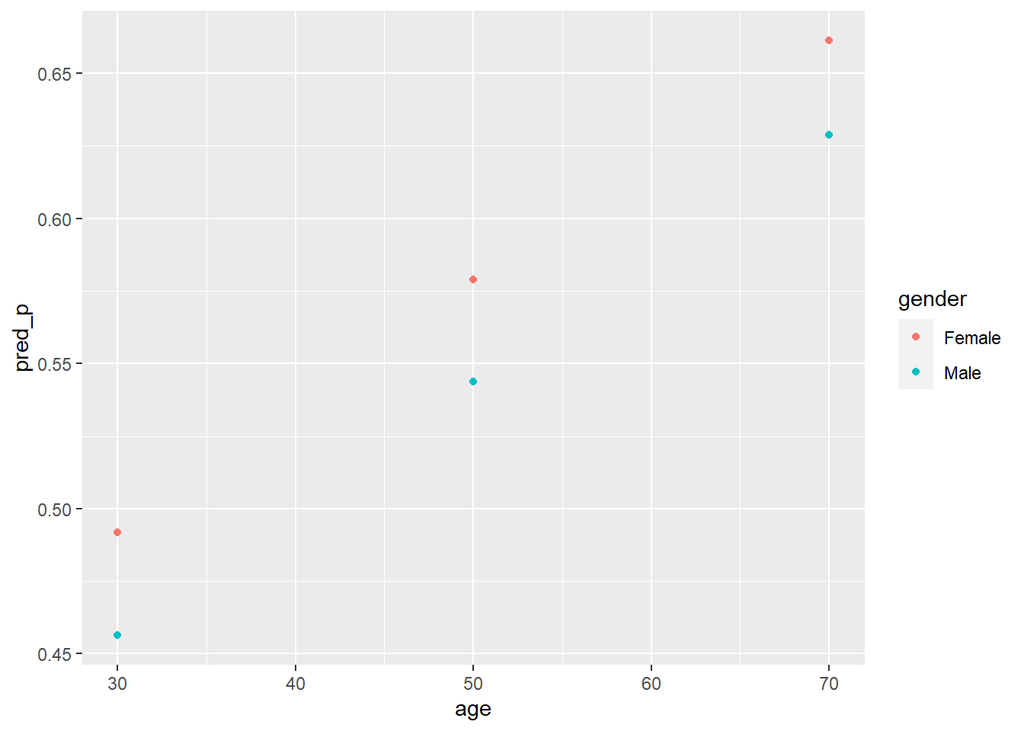

```r
# Visualize these model results
ggplot(pred_dataset,
       aes(x=age, y=pred_p, color=gender)) +
  geom_point()
```

# Model predictions for each person in the dataset

We can take the same approach to make model predictions for each person in the original data set. If we do not use the argument new data = , then the default is to make predictions for the existing data set.

```r
# make predictions for the original data
sale_df[,list(customer_id,
              pred_sale=predict(mod2,type = 'response'))]
```

```
##       customer_id pred_sale
##    1:      100000 0.5953627
##    2:      100001 0.6651535
##    3:      100002 0.5568251
##    4:      100003 0.5868824
##    5:      100004 0.5953627
##   ---
## 7996:      109995 0.5740663
## 7997:      109996 0.6805978
## 7998:      109997 0.5783503
## 7999:      109998 0.6037863
## 8000:      109999 0.5263459
```

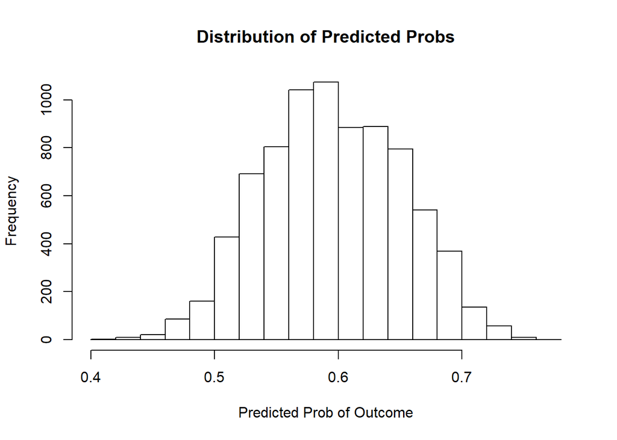

[output not shown]

```r
# Check out the distribution of predictions
sale_df[,hist(predict(mod2,type = 'response'),
              breaks = 20,
              main='Distribution of Predicted Probs',
              xlab = 'Predicted Prob of Outcome')]
```

# Adding non-linear terms and exploring residuals.

- Let’s look at age in the model - what should the functional form of age be for this model?

```r
# fit  model
mod3 <-
  glm(sale=='Yes' ~ age,
      family = binomial(link = "logit"),
      data=sale_df)
summary(mod3)
```

```
##
## Call:
## glm(formula = sale == "Yes" ~ age, family = binomial(link = "logit"),
##     data = sale_df)
##
## Deviance Residuals:
##     Min       1Q   Median       3Q      Max
## -1.7180  -1.3022   0.9235   1.0251   1.3409
##
## Coefficients:
##             Estimate Std. Error z value Pr(>|z|)
## (Intercept) -0.79997    0.12357  -6.474 9.56e-11 ***
## age          0.02016    0.00207   9.738  < 2e-16 ***
## ---
## Signif. codes:  0 '***' 0.001 '**' 0.01 '*' 0.05 '.' 0.1 ' ' 1
##
## (Dispersion parameter for binomial family taken to be 1)
##
##     Null deviance: 10796  on 7999  degrees of freedom
## Residual deviance: 10699  on 7998  degrees of freedom
## AIC: 10703
##
## Number of Fisher Scoring iterations: 4
```

- Age look significant! Does that mean the linear form of age is the correct model?
- Let’s try to make a plot of age versus sale. We end up with an odd plot - Sale only has values for 1 and 0!

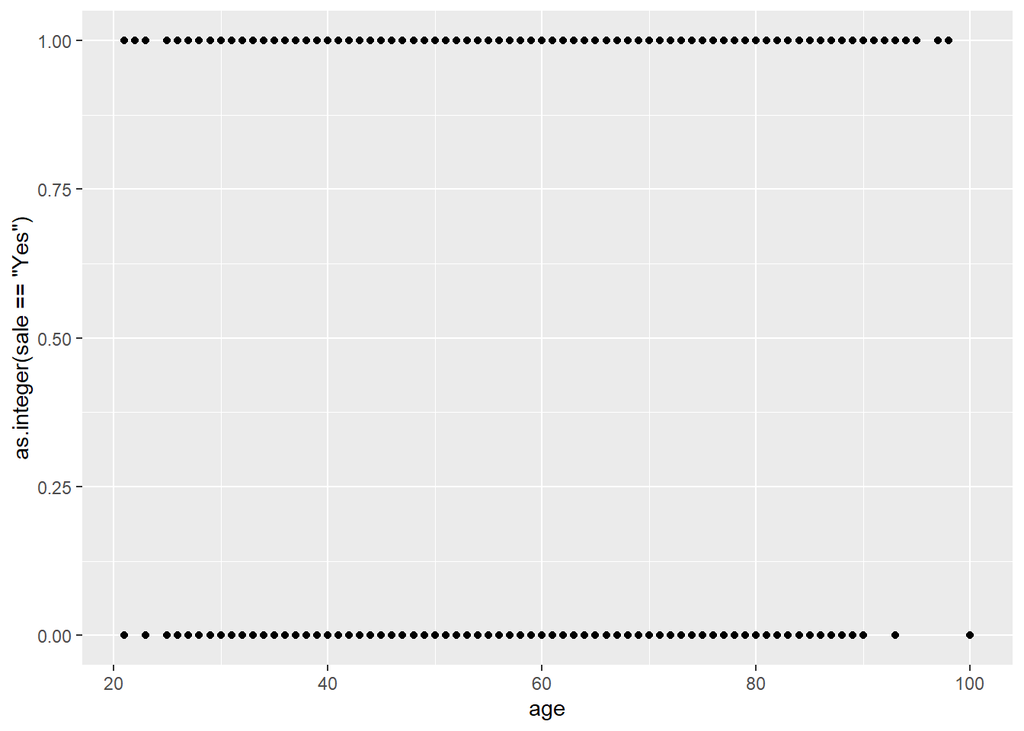

```r
# what do I make of this?
ggplot(sale_df,
       aes(x=age,y=as.integer(sale=='Yes'))) +
         geom_point()
```

- If we add a geom_smooth to this plot, we start to get an idea of the shape. But is the linear form of age appropriate?

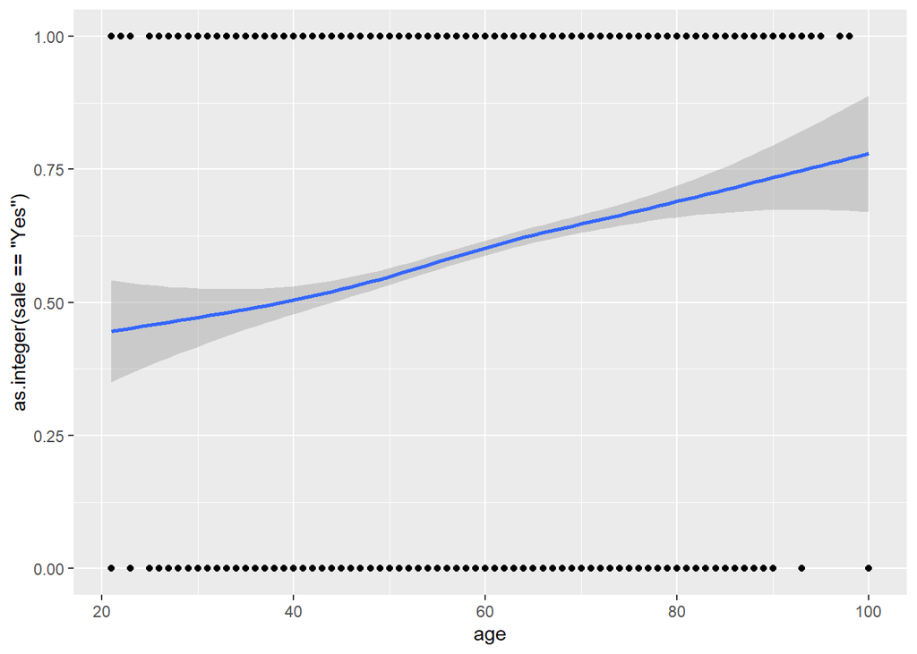

```r
# what do I make of this?
ggplot(sale_df,
       aes(x=age,y=as.integer(sale=='Yes'))) +
         geom_point() + geom_smooth()
```

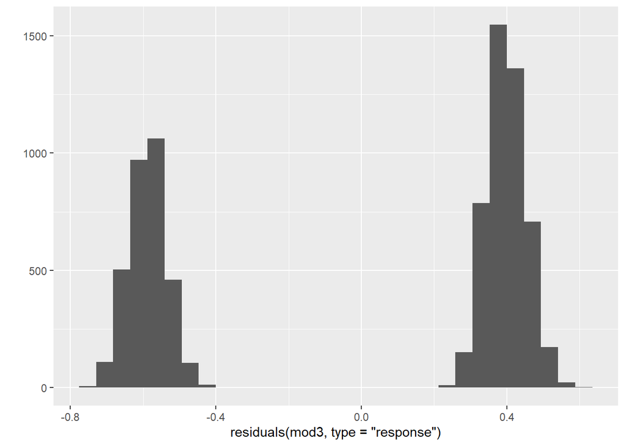

```r
# examine the residuals
qplot(residuals(mod3, type='response'))
```

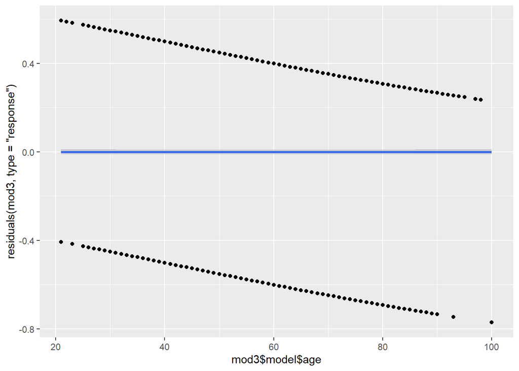

```r
# plot against age?
qplot(mod3$model$age,residuals(mod3, type='response')) +
  geom_smooth()
```

- These can be challenging to interpret! It looks like there is no systematic pattern to the residuals however - since there is a flat line across the middle. This indicates to me we likely have a good fit with the linear model.
- However…we could always do this check through the model and test a polynomial relationship:

```r
# fit  model
mod4 <-
  glm(sale=='Yes' ~ age + I(age**2),
      family = binomial(link = "logit"),
      data=sale_df)
summary(mod4)
```

```
##
## Call:
## glm(formula = sale == "Yes" ~ age + I(age^2), family = binomial(link = "logit"),
##     data = sale_df)
##
## Deviance Residuals:
##     Min       1Q   Median       3Q      Max
## -1.7488  -1.3003   0.9231   1.0272   1.3158
##
## Coefficients:
##               Estimate Std. Error z value Pr(>|z|)
## (Intercept) -0.6544555  0.4699548  -1.393    0.164
## age          0.0150327  0.0161188   0.933    0.351
## I(age^2)     0.0000436  0.0001359   0.321    0.748
##
## (Dispersion parameter for binomial family taken to be 1)
##
##     Null deviance: 10796  on 7999  degrees of freedom
## Residual deviance: 10699  on 7997  degrees of freedom
## AIC: 10705
##
## Number of Fisher Scoring iterations: 4
```

- We see here that age^2 is not significant in this model - so we may conclude that the linear predictor for age is the best functional form (of these two options!).

# Adding More Terms

- Let’s explore adding more terms to the model.
- We can use the same functions to explore this new model .

```r
# fit  model
mod5 <-
  glm(sale=='Yes' ~ gender + age + factor(region) + activity + marketing_exposure + x1
      + x2 + x3 + x4 + x5 + factor(num_accounts) + income,
      family = binomial(link = "logit"),
      data=sale_df)
summary(mod5)
```

```
##
## Call:
## glm(formula = sale == "Yes" ~ gender + age + factor(region) +
##     activity + marketing_exposure + x1 + x2 + x3 + x4 + x5 +
##     factor(num_accounts) + income, family = binomial(link = "logit"),
##     data = sale_df)
##
## Deviance Residuals:
##     Min       1Q   Median       3Q      Max
## -2.2188  -1.1489   0.6948   0.9816   1.9673
##
## Coefficients:
##                         Estimate Std. Error z value Pr(>|z|)
## (Intercept)           -2.7597739  0.3602890  -7.660 1.86e-14 ***
## genderMale            -0.1445133  0.0631956  -2.287 0.022210 *
## age                    0.0189253  0.0023966   7.897 2.86e-15 ***
## factor(region)2        1.3096344  0.2421779   5.408 6.38e-08 ***
## factor(region)3        0.0655352  0.2229634   0.294 0.768813
## factor(region)4        1.3902625  0.2399464   5.794 6.87e-09 ***
## factor(region)5        0.8147615  0.2320530   3.511 0.000446 ***
## factor(region)6        0.2974890  0.2325068   1.279 0.200726
## factor(region)7        1.3952995  0.2432400   5.736 9.68e-09 ***
## factor(region)8        0.4587443  0.2372445   1.934 0.053158 .
## factor(region)9        0.6466499  0.2282747   2.833 0.004615 **
## factor(region)10      -0.1342161  0.2333952  -0.575 0.565251
## factor(region)11       0.8104142  0.2312702   3.504 0.000458 ***
## factor(region)12       1.6042622  0.2482304   6.463 1.03e-10 ***
## factor(region)13       0.7434266  0.2304731   3.226 0.001257 **
## factor(region)14       1.4307534  0.2422325   5.907 3.49e-09 ***
## factor(region)15       0.7143845  0.2284413   3.127 0.001765 **
## factor(region)16       0.4819913  0.2319167   2.078 0.037682 *
## factor(region)17       1.1967192  0.2323473   5.151 2.60e-07 ***
## factor(region)18       0.7090203  0.2240148   3.165 0.001551 **
## factor(region)19       0.9925131  0.2380325   4.170 3.05e-05 ***
## factor(region)20       0.4600274  0.2324240   1.979 0.047787 *
## factor(region)21       0.9790823  0.2330368   4.201 2.65e-05 ***
## factor(region)22       1.2737982  0.2425808   5.251 1.51e-07 ***
## factor(region)23       0.6143084  0.2249787   2.731 0.006323 **
## factor(region)24       1.1343488  0.2354062   4.819 1.45e-06 ***
## factor(region)25       0.7582515  0.2390024   3.173 0.001511 **
```

[output cut: 33 more lines]

```
## factor(num_accounts)1  0.0033209  0.0535687   0.062 0.950568
## factor(num_accounts)2  0.1012541  0.0949881   1.066 0.286439
## factor(num_accounts)3 -0.1298971  0.2337493  -0.556 0.578408
## factor(num_accounts)4 -0.2706305  0.5629971  -0.481 0.630732
## income                -0.0009881  0.0024301  -0.407 0.684299
## ---
## Signif. codes:  0 '***' 0.001 '**' 0.01 '*' 0.05 '.' 0.1 ' ' 1
##
## (Dispersion parameter for binomial family taken to be 1)
##
##     Null deviance: 10795.9  on 7999  degrees of freedom
## Residual deviance:  9958.2  on 7935  degrees of freedom
## AIC: 10088
##
## Number of Fisher Scoring iterations: 4
```

- It looks like the majority of the items here are not significant. We can further explore this with type ‘3’ sum of squares tests. These can be interpreted as ‘How significant is this predictor if I were to leave it out. but leave everything else in?’. The advantage here is if there is a two degree of test required (like for activity), it will be calculated all at once instead of pairwise.

```r
# Check Anova
library(car)
res1 <- Anova(mod5, type = 'III')
res1
```

```
## Analysis of Deviance Table (Type III tests)
##
## Response: sale == "Yes"
##                      LR Chisq Df Pr(>Chisq)
## gender                   5.23  1     0.0222 *
## age                     63.09  1  1.974e-15 ***
## factor(region)         367.03 49  < 2.2e-16 ***
## activity               193.91  2  < 2.2e-16 ***
## marketing_exposure       0.00  1     0.9715
## x1                       0.40  1     0.5259
## x2                       0.02  1     0.8851
## x3                     182.96  1  < 2.2e-16 ***
## x4                       0.51  1     0.4767
## x5                       0.01  1     0.9154
## factor(num_accounts)     1.75  4     0.7812
## income                   0.17  1     0.6843
## ---
## Signif. codes:  0 '***' 0.001 '**' 0.01 '*' 0.05 '.' 0.1 ' ' 1
```

- To facilitate the comparison, we could even rank them from most significant to least significant. You can see that activity, x3, age, region, and gender are most significant, while the rest are not at all significant. You may decide to refit the model refit the model with just these terms (more on model selection like this in a later lecture).

```r
# rank these from most significant to least significant
res1[order(res1$`Pr(>Chisq)`),]
```

```
## Analysis of Deviance Table (Type III tests)
##
## Response: sale == "Yes"
##                      LR Chisq Df Pr(>Chisq)
## factor(region)         367.03 49  < 2.2e-16 ***
## activity               193.91  2  < 2.2e-16 ***
## x3                     182.96  1  < 2.2e-16 ***
## age                     63.09  1  1.974e-15 ***
## gender                   5.23  1     0.0222 *
## x4                       0.51  1     0.4767
## x1                       0.40  1     0.5259
## income                   0.17  1     0.6843
## factor(num_accounts)     1.75  4     0.7812
## x2                       0.02  1     0.8851
## x5                       0.01  1     0.9154
## marketing_exposure       0.00  1     0.9715
## ---
## Signif. codes:  0 '***' 0.001 '**' 0.01 '*' 0.05 '.' 0.1 ' ' 1
```

# Final Model and predictions

- Let’s fit a new model with just those terms, then make predictions for each person and explore them:

```r
# fancy code to construct this from the other object!
var_names <-
  row.names(res1[res1$`Pr(>Chisq)` < 0.2,])
# create formula
form1 <-
  as.Formula(paste('sale =="Yes" ~ ',paste(var_names,collapse = ' + ')))

# pass formula into model!
mod6 <-
  glm(form1,
      family = binomial(link = "logit"),
      data=sale_df)
summary(mod6)
```

```
##
## Call:
## glm(formula = form1, family = binomial(link = "logit"), data = sale_df)
##
## Deviance Residuals:
##     Min       1Q   Median       3Q      Max
## -2.2321  -1.1498   0.6954   0.9819   2.0151
##
## Coefficients:
##                   Estimate Std. Error z value Pr(>|z|)
## (Intercept)      -2.662617   0.260510 -10.221  < 2e-16 ***
## genderMale       -0.142531   0.054446  -2.618 0.008849 **
## age               0.018890   0.002396   7.884 3.16e-15 ***
## factor(region)2   1.306865   0.242005   5.400 6.66e-08 ***
## factor(region)3   0.070721   0.222877   0.317 0.751008
## factor(region)4   1.388839   0.239767   5.792 6.94e-09 ***
## factor(region)5   0.815978   0.231956   3.518 0.000435 ***
## factor(region)6   0.302162   0.232394   1.300 0.193529
## factor(region)7   1.394542   0.243068   5.737 9.62e-09 ***
## factor(region)8   0.463644   0.237038   1.956 0.050467 .
## factor(region)9   0.647229   0.228220   2.836 0.004568 **
## factor(region)10 -0.133267   0.233120  -0.572 0.567547
## factor(region)11  0.813361   0.231112   3.519 0.000433 ***
## factor(region)12  1.603889   0.248049   6.466 1.01e-10 ***
## factor(region)13  0.745071   0.230226   3.236 0.001211 **
## factor(region)14  1.428559   0.242028   5.902 3.58e-09 ***
## factor(region)15  0.714796   0.228230   3.132 0.001737 **
## factor(region)16  0.484713   0.231736   2.092 0.036469 *
## factor(region)17  1.194395   0.232209   5.144 2.69e-07 ***
## factor(region)18  0.704420   0.223810   3.147 0.001647 **
## factor(region)19  0.992141   0.237889   4.171 3.04e-05 ***
## factor(region)20  0.460221   0.232226   1.982 0.047504 *
## factor(region)21  0.980298   0.232904   4.209 2.56e-05 ***
## factor(region)22  1.281357   0.242359   5.287 1.24e-07 ***
## factor(region)23  0.607932   0.224775   2.705 0.006838 **
## factor(region)24  1.136823   0.235248   4.832 1.35e-06 ***
## factor(region)25  0.763620   0.238774   3.198 0.001383 **
## factor(region)26  0.718030   0.234040   3.068 0.002155 **
## factor(region)27  1.504250   0.252336   5.961 2.50e-09 ***
## factor(region)28  0.316505   0.228040   1.388 0.165157
```

[output cut: 20 more lines]

```
## factor(region)49  0.844885   0.237313   3.560 0.000371 ***
## factor(region)50  0.785112   0.236143   3.325 0.000885 ***
## activityLow      -0.881643   0.069134 -12.753  < 2e-16 ***
## activityMed      -0.338873   0.067065  -5.053 4.35e-07 ***
## x3                0.016496   0.001241  13.290  < 2e-16 ***
## ---
## Signif. codes:  0 '***' 0.001 '**' 0.01 '*' 0.05 '.' 0.1 ' ' 1
##
## (Dispersion parameter for binomial family taken to be 1)
##
##     Null deviance: 10795.9  on 7999  degrees of freedom
## Residual deviance:  9961.1  on 7945  degrees of freedom
## AIC: 10071
##
## Number of Fisher Scoring iterations: 4
```

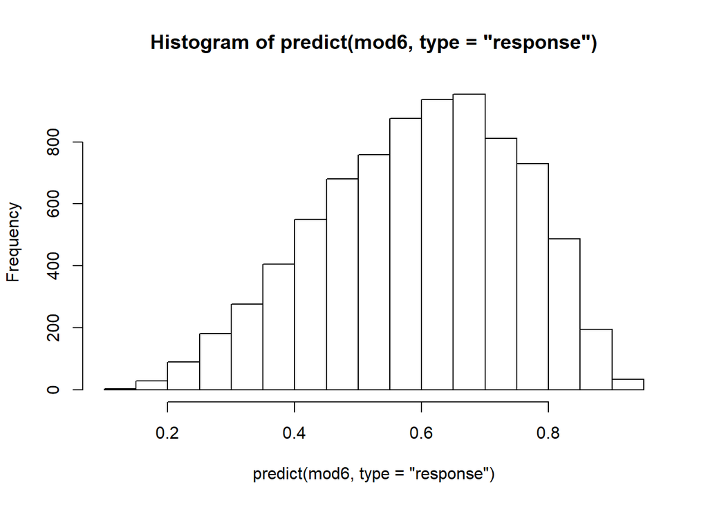

```r
# make predictions for each person based on this model
hist(predict(mod6,type='response'))
```

# Conclusion

- In this lecture you learned how logistic regression works and received a comprehensive overview of logistic regression.
- We started with understanding the general linear model (extensions to normal regression).
- We next reviewed the logit function to understand how the linear combination of predictors is connected to the outcome.
- We implemented increasingly complex logistic regression parameterizations and reviewed how to develop and interpret these models.
- You learned how to score new data in addition to the old data in the model.